# Diabetes_prediction

Importing all of the essential libraries as well as the diabetic dataset. The dataset's shape is (768, 9) which indicates it has 9 columns and 768 rows.

```python
import numpy as np
import pandas as pd # data processing, CSV file I/O (e.g. pd.read_csv)
import matplotlib.pyplot as plt #to plot charts
import seaborn as sns #used for data visualization
import warnings #avoid warning flash
warnings.filterwarnings('ignore')

from sklearn.preprocessing import MinMaxScaler

from sklearn.metrics import accuracy_score

from sklearn.metrics import confusion_matrix
from sklearn.metrics import plot_confusion_matrix
from sklearn.metrics import classification_report

from sklearn.neighbors import KNeighborsClassifier
from sklearn.ensemble import RandomForestClassifier
from sklearn.linear_model import LogisticRegression
from sklearn.svm import SVC
from sklearn import svm
from sklearn.model_selection import GridSearchCV
from sklearn.ensemble import VotingClassifier

from sklearn.metrics import plot_roc_curve
```

```python
df = pd.read_csv('pima-indians-diabetes.csv')
df.head()
```

|  | gnancies | glucose | diastolic | triceps | insulin | bmi | dpf | age | diabetes |
| --- | --- | --- | --- | --- | --- | --- | --- | --- | --- |
| 0 | 6 | 148 | 72 | 35 | 0 | 33.6 | 0.627 | 50 | 1 |
| 1 | 1 | 85 | 66 | 29 | 0 | 26.6 | 0.351 | 31 | 0 |
| 2 | 8 | 183 | 64 | 0 | 0 | 23.3 | 0.672 | 32 | 1 |
| 3 | 1 | 89 | 66 | 23 | 94 | 28.1 | 0.167 | 21 | 0 |
| 4 | 0 | 137 | 40 | 35 | 168 | 43.1 | 2.288 | 33 | 1 |

Since the dataset columns have spelling mistakes renaming it.

```python
df = df.rename(columns={"gnancies": "Pregnancies", "glucose": "Glucose", 'diastolic': 'BloodPressure', 'triceps':'SkinThickness','insulin':'Insulin','bmi':'BMI','dpf':'DiabetesPedigreeFunction','age':'Age','diabetes':'Outcome'})
df
```

|  | Pregnancies | Glucose | BloodPressure | SkinThickness | Insulin | BMI | DiabetesPedigreeFunction | Age | Outcome |
| --- | --- | --- | --- | --- | --- | --- | --- | --- | --- |
| 0 | 6 | 148 | 72 | 35 | 0 | 33.6 | 0.627 | 50 | 1 |
| 1 | 1 | 85 | 66 | 29 | 0 | 26.6 | 0.351 | 31 | 0 |
| 2 | 8 | 183 | 64 | 0 | 0 | 23.3 | 0.672 | 32 | 1 |
| 3 | 1 | 89 | 66 | 23 | 94 | 28.1 | 0.167 | 21 | 0 |
| 4 | 0 | 137 | 40 | 35 | 168 | 43.1 | 2.288 | 33 | 1 |
| ... | ... | ... | ... | ... | ... | ... | ... | ... | ... |
| 763 | 10 | 101 | 76 | 48 | 180 | 32.9 | 0.171 | 63 | 0 |
| 764 | 2 | 122 | 70 | 27 | 0 | 36.8 | 0.340 | 27 | 0 |
| 765 | 5 | 121 | 72 | 23 | 112 | 26.2 | 0.245 | 30 | 0 |
| 766 | 1 | 126 | 60 | 0 | 0 | 30.1 | 0.349 | 47 | 1 |
| 767 | 1 | 93 | 70 | 31 | 0 | 30.4 | 0.315 | 23 | 0 |

768 rows × 9 columns

```python
df.shape
```

```
(768, 9)
```

```python
df.info()
```

```
<class 'pandas.core.frame.DataFrame'>
RangeIndex: 768 entries, 0 to 767
Data columns (total 9 columns):
 #   Column                    Non-Null Count  Dtype
---  ------                    --------------  -----
 0   Pregnancies               768 non-null    int64
 1   Glucose                   768 non-null    int64
 2   BloodPressure             768 non-null    int64
 3   SkinThickness             768 non-null    int64
 4   Insulin                   768 non-null    int64
 5   BMI                       768 non-null    float64
 6   DiabetesPedigreeFunction  768 non-null    float64
 7   Age                       768 non-null    int64
 8   Outcome                   768 non-null    int64
dtypes: float64(2), int64(7)
memory usage: 54.1 KB
```

This part of the code tells the type of the data. It says the columns DiabetesPedigreeFunction and BMI are in datatype float, and other columns datatypes are integers.

```python
def missing_duplicate_values(x):
    print('Null values:\n')
    print(x.isnull().sum(),'\n')
    print('*'*50)
    print(x.isna().sum(),'\n')
    print('*'*50)
    print('Duplicated values =', x.duplicated().sum())

missing_duplicate_values(df)
```

```
Null values:

Pregnancies                 0
Glucose                     0
BloodPressure               0
SkinThickness               0
Insulin                     0
BMI                         0
DiabetesPedigreeFunction    0
Age                         0
Outcome                     0
dtype: int64

Pregnancies                 0
Glucose                     0
BloodPressure               0
SkinThickness               0
Insulin                     0
BMI                         0
DiabetesPedigreeFunction    0
Age                         0
Outcome                     0
dtype: int64

Duplicated values = 0
```

There are no missing and duplicated values presented in the dataset.

```python
df.describe()
```

|  | Pregnancies | Glucose | BloodPressure | SkinThickness | Insulin | BMI | DiabetesPedigreeFunction | Age | Outcome |
| --- | --- | --- | --- | --- | --- | --- | --- | --- | --- |
| count | 768.000000 | 768.000000 | 768.000000 | 768.000000 | 768.000000 | 768.000000 | 768.000000 | 768.000000 | 768.000000 |
| mean | 3.845052 | 120.894531 | 69.105469 | 20.536458 | 79.799479 | 31.992578 | 0.471876 | 33.240885 | 0.348958 |
| std | 3.369578 | 31.972618 | 19.355807 | 15.952218 | 115.244002 | 7.884160 | 0.331329 | 11.760232 | 0.476951 |
| min | 0.000000 | 0.000000 | 0.000000 | 0.000000 | 0.000000 | 0.000000 | 0.078000 | 21.000000 | 0.000000 |
| 25% | 1.000000 | 99.000000 | 62.000000 | 0.000000 | 0.000000 | 27.300000 | 0.243750 | 24.000000 | 0.000000 |
| 50% | 3.000000 | 117.000000 | 72.000000 | 23.000000 | 30.500000 | 32.000000 | 0.372500 | 29.000000 | 0.000000 |
| 75% | 6.000000 | 140.250000 | 80.000000 | 32.000000 | 127.250000 | 36.600000 | 0.626250 | 41.000000 | 1.000000 |
| max | 17.000000 | 199.000000 | 122.000000 | 99.000000 | 846.000000 | 67.100000 | 2.420000 | 81.000000 | 1.000000 |

We can see there are values '0' presented in the dataset since the columns Pregnancies, Glucose, blood pressure, skin thickness, Insulin, BMI, and Outcome have minimum values as 0. We cannot find the patterns if the dataset has '0' values in it. Therefore, replacing all the '0' values.

```python
print('The column Glucose has',df[df['Glucose']==0].shape[0], '0 Values')
print('The column BloodPressure has',df[df['BloodPressure']==0].shape[0],'0 Values')
print('The column SkinThickness has',df[df['SkinThickness']==0].shape[0],'0 Values')
print('The column Insulin has',df[df['Insulin']==0].shape[0],'0 Values')
print('The column BMI has',df[df['BMI']==0].shape[0],'0 Values')
```

```
The column Glucose has 5 0 Values
The column BloodPressure has 35 0 Values
The column SkinThickness has 227 0 Values
The column Insulin has 374 0 Values
The column BMI has 11 0 Values
```

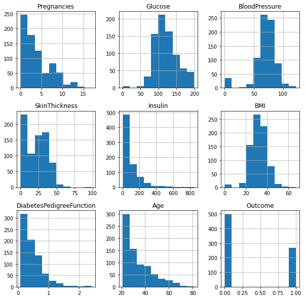

```python
df.hist(bins=10,figsize=(10,10))
plt.show()
```

```python
df.skew()
```

```
Pregnancies                 0.901674
Glucose                     0.173754
BloodPressure              -1.843608
SkinThickness               0.109372
Insulin                     2.272251
BMI                        -0.428982
DiabetesPedigreeFunction    1.919911
Age                         1.129597
Outcome                     0.635017
dtype: float64
```

```python
df['Glucose']=df['Glucose'].replace(0,df['Glucose'].median())#skewed distribution
df['BloodPressure']=df['BloodPressure'].replace(0,df['BloodPressure'].median())#skewed distribution
df['BMI']=df['BMI'].replace(0,df['BMI'].mean())#normal distribution
df['SkinThickness']=df['SkinThickness'].replace(0,df['SkinThickness'].median())#skewed distribution
df['Insulin']=df['Insulin'].replace(0,df['Insulin'].median())#skewed distribution
```

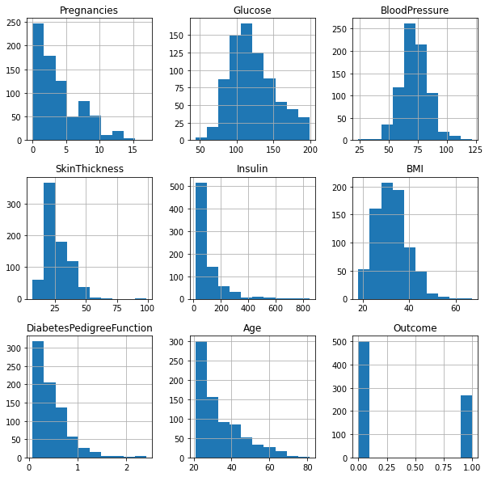

```python
df.hist(bins=10,figsize=(10,10))
plt.show()
```

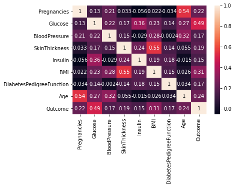

```python
sns.heatmap(df.corr(), annot=True)
```

The heatmap above explains that the feature columns are not correlated since none of the values is nearby -1 and 1.

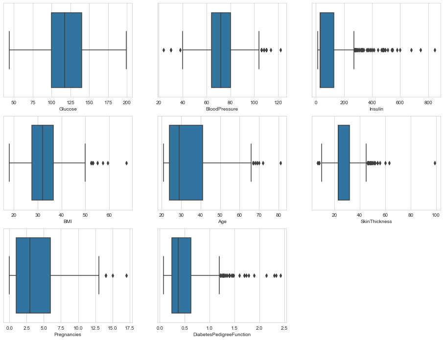

```python
plt.figure(figsize=(16,12))

sns.set_style(style='whitegrid')
plt.subplot(3,3,1)
sns.boxplot(x='Glucose',data=df)

plt.subplot(3,3,2)
sns.boxplot(x='BloodPressure',data=df)

plt.subplot(3,3,3)
sns.boxplot(x='Insulin',data=df)

plt.subplot(3,3,4)
sns.boxplot(x='BMI',data=df)

plt.subplot(3,3,5)
sns.boxplot(x='Age',data=df)

plt.subplot(3,3,6)
sns.boxplot(x='SkinThickness',data=df)

plt.subplot(3,3,7)
sns.boxplot(x='Pregnancies',data=df)

plt.subplot(3,3,8)
sns.boxplot(x='DiabetesPedigreeFunction',data=df)
```

Removing the outliers: IQR Method - The rule of thumb is that anything not in the range of (𝑄1−1.5𝐼𝑄𝑅) and (𝑄3+1.5𝐼𝑄𝑅) is an outlier, and can be removed. Post removing outliers our shape of the dataset is changed to (636, 9).

```python
Q1 = df.quantile(0.25)
Q3 = df.quantile(0.75)
IQR = Q3 - Q1
print(IQR)
```

```
Pregnancies                  5.0000
Glucose                     40.5000
BloodPressure               16.0000
SkinThickness                9.0000
Insulin                     96.7500
BMI                          9.1000
DiabetesPedigreeFunction     0.3825
Age                         17.0000
Outcome                      1.0000
dtype: float64
```

```python
df_out = df[~((df < (Q1 - 1.5 * IQR)) | (df > (Q3 + 1.5 * IQR))).any(axis=1)]
print(f'Before: {df.shape}, After: {df_out.shape}')
```

```
Before: (768, 9), After: (636, 9)
```

```python
dfq = df_out.to_excel("output.xlsx")
```

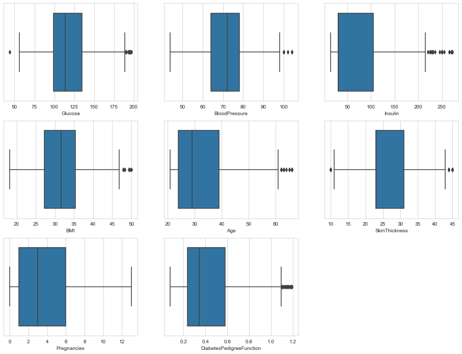

```python
plt.figure(figsize=(16,12))

sns.set_style(style='whitegrid')
plt.subplot(3,3,1)
sns.boxplot(x='Glucose',data=df_out)

plt.subplot(3,3,2)
sns.boxplot(x='BloodPressure',data=df_out)

plt.subplot(3,3,3)
sns.boxplot(x='Insulin',data=df_out)

plt.subplot(3,3,4)
sns.boxplot(x='BMI',data=df_out)

plt.subplot(3,3,5)
sns.boxplot(x='Age',data=df_out)

plt.subplot(3,3,6)
sns.boxplot(x='SkinThickness',data=df_out)

plt.subplot(3,3,7)
sns.boxplot(x='Pregnancies',data=df_out)

plt.subplot(3,3,8)
sns.boxplot(x='DiabetesPedigreeFunction',data=df_out)
```

```
0    435
1    201
Name: Outcome, dtype: int64
```

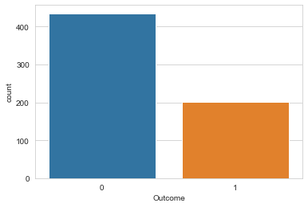

```python
print(df_out['Outcome'].value_counts())
sns.countplot('Outcome',data=df_out)
```

Data Normalisation: We can see on the below plot that the dataset is not normally distributed. Hence, Using MinMaxScaler to scale the data

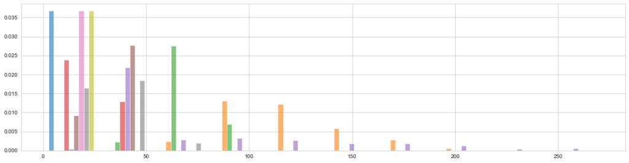

```python
plt.figure(figsize= (20,5))
plt.hist(df_out, density=True, alpha=0.6)

plt.show()
```

```python
X = df_out[df_out.columns[:-1]]
y = df_out['Outcome']
```

```python
scaled = MinMaxScaler()
X = scaled.fit_transform(X)
X
```

```
array([[0.46153846, 0.67973856, 0.46666667, ..., 0.48427673, 0.49326146,
        0.64444444],
       [0.07692308, 0.26797386, 0.36666667, ..., 0.26415094, 0.24528302,
        0.22222222],
       [0.61538462, 0.90849673, 0.33333333, ..., 0.16037736, 0.53369272,
        0.24444444],
       ...,
       [0.38461538, 0.50326797, 0.46666667, ..., 0.25157233, 0.15004492,
        0.2       ],
       [0.07692308, 0.53594771, 0.26666667, ..., 0.37421384, 0.24348607,
        0.57777778],
       [0.07692308, 0.32026144, 0.43333333, ..., 0.3836478 , 0.21293801,
        0.04444444]])
```

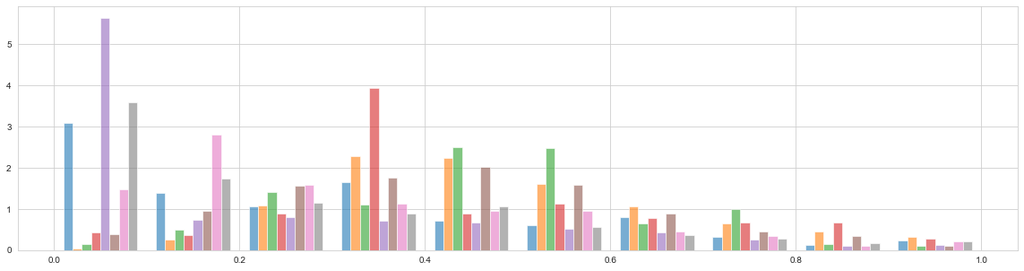

```python
plt.figure(figsize= (20,5))
plt.hist(X, density=True, alpha=0.6)

plt.show()
```

Splitting the data: Separating data into training and testing sets is an important part of evaluating data mining models. Typically, when you separate a data set into a training set and testing set, most of the data is used for training, and a smaller portion of the data is used for testing.

### First method - Classic 70/30

```python
from sklearn.model_selection import train_test_split

X_train1,X_test1, y_train1,y_test1 = train_test_split(X,y, test_size = 0.3, random_state = 42)

print(X_train1.shape,X_test1.shape,y_train1.shape,y_test1.shape)
```

```
(445, 8) (191, 8) (445,) (191,)
```

## Second Method - K- Fold

```python
import numpy as np
from sklearn.model_selection import KFold


kf = KFold(n_splits=3)
for train, test in kf.split(X):
    print("%s %s" % (train, test))

y = np.array(y)#changing the y variable to array
X_train2, X_test2, y_train2, y_test2 = X[train], X[test], y[train], y[test]
print(X_train2.shape,X_test2.shape,y_train2.shape,y_test2.shape)
```

[output not shown]

[output cut: 91 more lines]

### Model Creation

```python
def Voting_classifier(X_train,X_test,y_train,y_test):


    knn_model = KNeighborsClassifier(n_neighbors=3)
    knn_model.fit(X_train, y_train)

    log_model = LogisticRegression()
    log_model.fit(X_train, y_train)

    rf_model= RandomForestClassifier(max_depth=2, random_state=0)
    rf_model.fit(X_train, y_train)

    svm_model = svm.SVC(kernel='linear',probability = True)
    svm_model.fit(X_train, y_train)

    y_pred_knn = knn_model.predict(X_test)
    y_pred_log = log_model.predict(X_test)
    y_pred_rf = rf_model.predict(X_test)
    y_pred_svm = svm_model.predict(X_test)

    knn_score = accuracy_score(y_test, y_pred_knn)
    log_score = accuracy_score(y_test, y_pred_log)
    rf_score = accuracy_score(y_test, y_pred_rf)
    svm_score = accuracy_score(y_test, y_pred_svm)

    print("Accuracy score (KNN): ", knn_score)
    print("Accuracy score (Logistic): ", log_score)
    print("Accuracy score (Randon Forest): ", rf_score)
    print("Accuracy score (SVM): ", svm_score)



    knn_Cm = confusion_matrix(y_test, y_pred_knn)
    LR_CM= confusion_matrix(y_test, y_pred_log)
    RF_CM =confusion_matrix(y_test, y_pred_rf)
    SVM_CM = confusion_matrix(y_test, y_pred_svm)



    #create a dictionary of our models
    estimators=[('knn', knn_model), ('rf', log_model), ('log_reg', rf_model),('svm',svm_model)]
    #create our voting classifier, inputting our models
    ensemble = VotingClassifier(estimators, voting='soft')
    #fit model to training data
    ensemble.fit(X_train, y_train)
    #test our model on the test data

    Voting_prediction = ensemble.predict(X_test)

    Voting_final = accuracy_score(y_test, Voting_prediction)
    print("Accuracy score for (Voting_model) without Grid search: ", Voting_final)

    Voting_accuracy_matrix = confusion_matrix(y_test, Voting_prediction)
    sns.heatmap(pd.DataFrame(Voting_accuracy_matrix), annot = True,cmap="YlGnBu" ,fmt='g').set_title('Voting_Classifier')

    print("Test Classification Report for model Voting \n",classification_report(y_test, Voting_prediction))
    plot_roc_curve(ensemble, X_test, y_test)
```

```python
def Grid_voting_classifier(X_train,X_test,y_train,y_test):
    global GridSearchCV

    knn = KNeighborsClassifier()#create a dictionary of all values we want to test for n_neighbors
    params_knn = {'n_neighbors': np.arange(1, 25)}#use gridsearch to test all values for n_neighbors
    knn_gs = GridSearchCV(knn, params_knn, cv=5)#fit model to training data
    knn_gs.fit(X_train, y_train)

    knn_best = knn_gs.best_estimator_

    print('Best k value for',knn_gs.best_params_)

    rf = RandomForestClassifier()
    #create a dictionary of all values we want to test for n_estimators
    params_rf = {'n_estimators': [50, 100,200,250,300,350,400]}
    #use gridsearch to test all values for n_estimators
    rf_gs = GridSearchCV(rf, params_rf, cv=5)#fit model to training data
    rf_gs.fit(X_train, y_train)

    #save best model
    rf_best = rf_gs.best_estimator_
    #check best n_estimators value
    print(rf_gs.best_params_)

    from sklearn.model_selection import GridSearchCV
    log_reg = LogisticRegression()
    grid_values = {'C':[0.001,.009,0.01,.09,1,5,10,25,50,70]}
    log_reg = GridSearchCV(log_reg, param_grid = grid_values,scoring = 'recall')
    log_reg.fit(X_train, y_train)

    print('Best Estimators: %s' % log_reg.best_estimator_)
    print('Best Score: %s' % log_reg.best_score_)

    best_log_reg = log_reg.best_estimator_

    param_grid = {'C': [0.1,1, 10, 100], 'gamma': [1,0.1,0.01,0.001],'kernel': ['rbf', 'poly', 'sigmoid']}
    svm_grid = GridSearchCV(SVC(probability=True),param_grid,refit=True,verbose=2)
    svm_grid.fit(X_train,y_train)

    import pickle
    pickle.dump(svm_grid, open('svm_grid_model.pkl','wb'))
    print("dumping complete")

    print(svm_grid.best_estimator_)
    svm_grid= svm_grid.best_estimator_


    estimators=[('knn', knn_best), ('rf', rf_best), ('log_reg', best_log_reg),('svm',svm_grid)]
    #create our voting classifier, inputting our models
    ensemble = VotingClassifier(estimators, voting='soft')
    #fit model to training data
    ensemble.fit(X_train, y_train)
    #test our model on the test data

    Voting_prediction = ensemble.predict(X_test)

    Voting_final = accuracy_score(y_test, Voting_prediction)
    print("Accuracy score after grid search(Voting_model): ", Voting_final)

    Voting_accuracy_matrix = confusion_matrix(y_test, Voting_prediction)
    Voting_accuracy_matrix

    sns.heatmap(pd.DataFrame(Voting_accuracy_matrix), annot = True,cmap="YlGnBu" ,fmt='g').set_title('Voting_Classifier')
    plot_roc_curve(ensemble, X_test, y_test)
```

# Calling the function for the classic 70/30 method

```
Accuracy score (KNN):  0.7643979057591623
Accuracy score (Logistic):  0.7696335078534031
Accuracy score (Randon Forest):  0.7172774869109948
Accuracy score (SVM):  0.774869109947644
Accuracy score for (Voting_model) without Grid search:  0.774869109947644
Test Classification Report for model Voting
               precision    recall  f1-score   support

           0       0.77      0.95      0.85       127
           1       0.82      0.42      0.56        64

    accuracy                           0.77       191
   macro avg       0.79      0.69      0.70       191
weighted avg       0.78      0.77      0.75       191
```

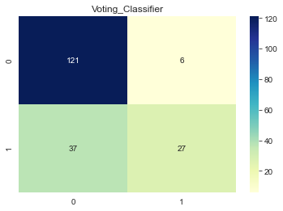

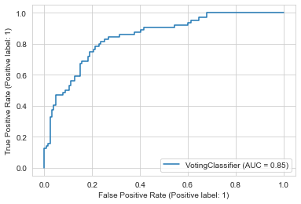

```python
Voting_classifier(X_train1,X_test1,y_train1,y_test1)
```

# Grid classification for classic 70/30 split method

[output not shown]

[output cut: 193 more lines]

[output not shown]

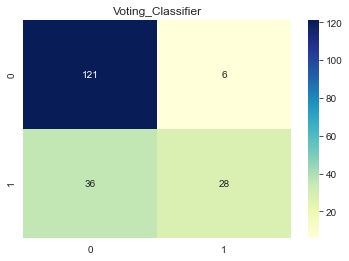

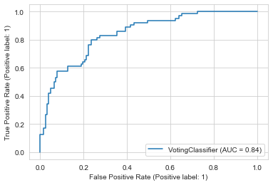

```python
Grid_voting_classifier(X_train1,X_test1,y_train1,y_test1)
```

# Calling the function for the K-fold method

```
Accuracy score (KNN):  0.7688679245283019
Accuracy score (Logistic):  0.7924528301886793
Accuracy score (Randon Forest):  0.7405660377358491
Accuracy score (SVM):  0.8018867924528302
Accuracy score for (Voting_model) without Grid search:  0.7971698113207547
Test Classification Report for model Voting
               precision    recall  f1-score   support

           0       0.81      0.93      0.87       148
           1       0.76      0.48      0.59        64

    accuracy                           0.80       212
   macro avg       0.78      0.71      0.73       212
weighted avg       0.79      0.80      0.78       212
```

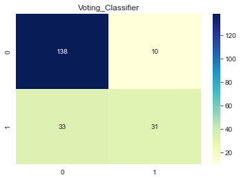

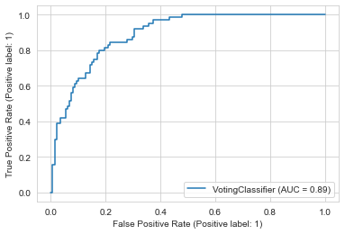

```python
Voting_classifier(X_train2,X_test2,y_train2,y_test2)
```

# Grid classification for classic K-fold split method

[output not shown]

[output cut: 193 more lines]

[output not shown]

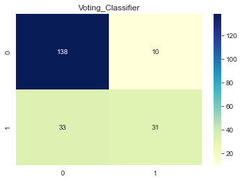

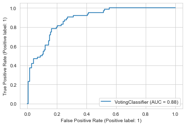

```python
Grid_voting_classifier(X_train2,X_test2,y_train2,y_test2)
```